# Vauld_Data_Exercise

## Prepared by Abhishek Kumar

#### https://bit.ly/AKSLinkedIn

```python
# To get multiple outputs in the same cell

from IPython.core.interactiveshell import InteractiveShell
InteractiveShell.ast_node_interactivity = "all"
```

```python
# Import libraries

import pandas as pd
import numpy as np
import sqlite3 as sql
import matplotlib.pyplot as plt
import seaborn as sns
%matplotlib inline
```

```python
# Creating a database for Vauld

conn = sql.connect('vauld.db')
```

## -----------------------------------------------------------------------------------------------------------------------------

## Part 1

## -----------------------------------------------------------------------------------------------------------------------------

Question 1

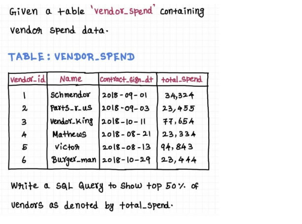

### Data Preparation

```python
data = {'vendor_id':[1,2,3,4,5,6],
       'name':['Schmendor','Parts_r_us','Vendor_king','Mathews','Victor','Burger_man'],
       'contract_sign_dt':['2018-9-1','2018-9-3','2018-10-11','2018-8-21','2018-8-13','2018-10-29'],
       'total_spend':[34324,23455,77654,23334,94843,23444]}
vendor_spend = pd.DataFrame(data)
vendor_spend['contract_sign_dt'] = pd.to_datetime(vendor_spend.contract_sign_dt)
```

```python
vendor_spend.shape
vendor_spend
```

```
(6, 4)
```

|  | vendor_id | name | contract_sign_dt | total_spend |
| --- | --- | --- | --- | --- |
| 0 | 1 | Schmendor | 2018-09-01 | 34324 |
| 1 | 2 | Parts_r_us | 2018-09-03 | 23455 |
| 2 | 3 | Vendor_king | 2018-10-11 | 77654 |
| 3 | 4 | Mathews | 2018-08-21 | 23334 |
| 4 | 5 | Victor | 2018-08-13 | 94843 |
| 5 | 6 | Burger_man | 2018-10-29 | 23444 |

### Python Implementation

```python
vendor_spend[vendor_spend.total_spend>np.median(vendor_spend.total_spend)]
```

|  | vendor_id | name | contract_sign_dt | total_spend |
| --- | --- | --- | --- | --- |
| 0 | 1 | Schmendor | 2018-09-01 | 34324 |
| 2 | 3 | Vendor_king | 2018-10-11 | 77654 |
| 4 | 5 | Victor | 2018-08-13 | 94843 |

### SQL Implementation

```python
# Creating the weather table in vauld database
vendor_spend.to_sql('vendor_spend',conn,if_exists='replace',index=False)
```

```python
# Query prepartion
query = '''

select vendor_id,name,contract_sign_dt,total_spend
from (select *, percent_rank() over (order by total_spend) as percntile from vendor_spend) as per
where percntile > 0.5

'''
```

```python
# Passing the query to vauld db for execution

result = pd.read_sql(query,conn)
result
```

|  | vendor_id | name | contract_sign_dt | total_spend |
| --- | --- | --- | --- | --- |
| 0 | 1 | Schmendor | 2018-09-01 00:00:00 | 34324 |
| 1 | 3 | Vendor_king | 2018-10-11 00:00:00 | 77654 |
| 2 | 5 | Victor | 2018-08-13 00:00:00 | 94843 |

**Result** - Vendor 1, 3 and 5 are the top 50% spender

Question 2

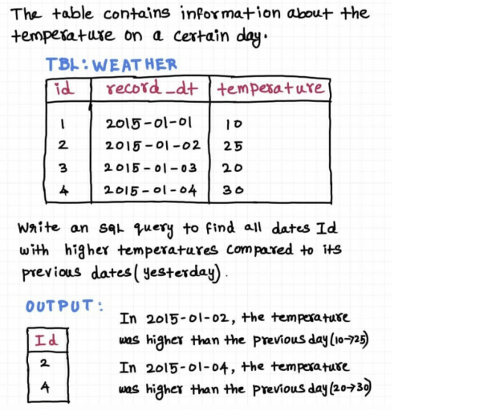

### Data Preparation

```python
data = {'id':[1,2,3,4,5,6],
       'record_dt':['2015-1-1','2015-1-2','2015-1-3','2015-1-4','2015-1-5','2018-1-6'],
       'temperature':[10,25,20,30,28,27]}
weather = pd.DataFrame(data)
weather['record_dt'] = pd.to_datetime(weather.record_dt)
```

```python
weather.shape
weather
```

```
(6, 3)
```

|  | id | record_dt | temperature |
| --- | --- | --- | --- |
| 0 | 1 | 2015-01-01 | 10 |
| 1 | 2 | 2015-01-02 | 25 |
| 2 | 3 | 2015-01-03 | 20 |
| 3 | 4 | 2015-01-04 | 30 |
| 4 | 5 | 2015-01-05 | 28 |
| 5 | 6 | 2018-01-06 | 27 |

### Python Implementation

```python
# Python Implementation
weather_py = weather.copy()
weather_py['prev_temp'] = weather_py.sort_values('record_dt').temperature.shift(1)
weather_py[weather_py.temperature > weather_py.prev_temp]['id'].to_frame()
```

|  | id |
| --- | --- |
| 1 | 2 |
| 3 | 4 |

### SQL Implementation

```python
# Creating the weather table in vauld database
weather.to_sql('weather',conn,if_exists='replace',index=False)
```

```python
# Query prepartion
query = '''

select id
from (select *, lag(temperature) over (order by record_dt) as prev_temp from weather) as lag
where temperature > prev_temp


'''
```

```python
# Passing the query to vauld db for execution

result = pd.read_sql(query,conn)
result
```

|  | id |
| --- | --- |
| 0 | 2 |
| 1 | 4 |

**Result** - The days with ID value 2 and 4 have higher temperatures than their previous days respectively.

## -----------------------------------------------------------------------------------------------------------------------------

## Part 2

## -----------------------------------------------------------------------------------------------------------------------------

Question

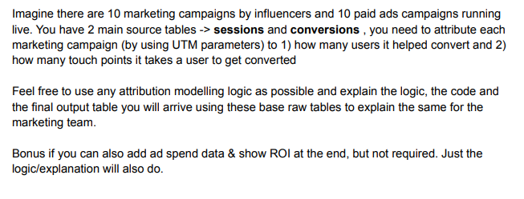

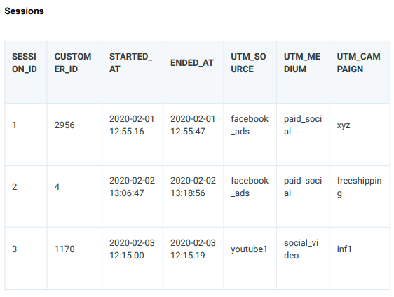

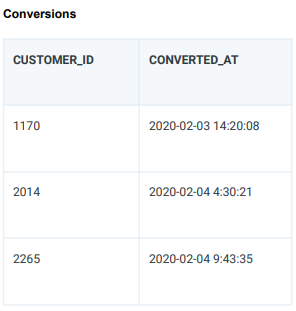

### Data Preparation

```python
sessions = pd.read_excel('./one.xlsx', sheet_name='sessions')
sessions['Started_At'] = pd.to_datetime(sessions.Started_At)
sessions['Ended_At'] = pd.to_datetime(sessions.Ended_At)
sessions
```

|  | Session_Id | Customer_Id | Started_At | Ended_At | UTM_Source | UTM_Medium | UTM_Campaign |
| --- | --- | --- | --- | --- | --- | --- | --- |
| 0 | 1 | 2956 | 2020-02-01 12:55:16 | 2020-02-01 12:55:47 | facebook_ads | paid_social | xyz |
| 1 | 2 | 4 | 2020-02-02 13:06:47 | 2020-02-02 13:18:56 | facebook_ads | paid_social | freeshipping |
| 2 | 3 | 1170 | 2020-02-03 12:15:00 | 2020-02-03 12:15:19 | insta | social_video | freeshipping |
| 3 | 4 | 1170 | 2020-02-03 12:21:00 | 2020-02-03 12:25:19 | youtube | social_video | inf1 |
| 4 | 5 | 2014 | 2020-02-04 04:20:21 | 2020-02-04 04:36:21 | facebook_ads | paid_social | freeshipping |
| 5 | 6 | 1170 | 2020-02-05 12:13:00 | 2020-02-05 12:15:54 | youtube | social_video | inf1 |

```python
conversions = pd.read_excel('./one.xlsx', sheet_name='conversions')
conversions['converted_at'] = pd.to_datetime(conversions.converted_at)
conversions['customer_id'] = conversions.customer_id.astype('int')
conversions
```

|  | customer_id | converted_at |
| --- | --- | --- |
| 0 | 2014 | 2020-02-04 04:30:21 |
| 1 | 2265 | 2020-02-04 09:43:35 |
| 2 | 1170 | 2020-02-05 12:15:19 |

```python
# Creating the sessions and conversions table in vauld database
sessions.to_sql('sessions',conn,if_exists='replace',index=False)
conversions.to_sql('conversions',conn,if_exists='replace',index=False)
```

```python
# user defined function to execute query
def run(query, conn=conn):
    # Passing the query to vauld db for execution
    result = pd.read_sql(query,conn)
    return result
```

### SQL Implementation

```python
# Query prepartion : Data overview
query = '''

select s.* , case when converted_at between Started_At and Ended_At then 1 else 0 end as flag
from sessions s left join conversions c
on s.customer_id = c.customer_id

'''
```

```python
run(query)
```

|  | Session_Id | Customer_Id | Started_At | Ended_At | UTM_Source | UTM_Medium | UTM_Campaign | flag |
| --- | --- | --- | --- | --- | --- | --- | --- | --- |
| 0 | 1 | 2956 | 2020-02-01 12:55:16 | 2020-02-01 12:55:47 | facebook_ads | paid_social | xyz | 0 |
| 1 | 2 | 4 | 2020-02-02 13:06:47 | 2020-02-02 13:18:56 | facebook_ads | paid_social | freeshipping | 0 |
| 2 | 3 | 1170 | 2020-02-03 12:15:00 | 2020-02-03 12:15:19 | insta | social_video | freeshipping | 0 |
| 3 | 4 | 1170 | 2020-02-03 12:21:00 | 2020-02-03 12:25:19 | youtube | social_video | inf1 | 0 |
| 4 | 5 | 2014 | 2020-02-04 04:20:21 | 2020-02-04 04:36:21 | facebook_ads | paid_social | freeshipping | 1 |
| 5 | 6 | 1170 | 2020-02-05 12:13:00 | 2020-02-05 12:15:54 | youtube | social_video | inf1 | 1 |

**Question 1 - how many users it helped convert**

```python
# Query prepartion : Conversion Rate by Campaign

query = '''

select UTM_Campaign, count(distinct Customer_Id) as targeted_customer_count, sum(flag) as conversion_count,
sum(flag)*100 / count(distinct Customer_Id) as conversion_pct
from (
select s.* , case when converted_at between Started_At and Ended_At then 1 else 0 end as flag
from sessions s left join conversions c
on s.customer_id = c.customer_id )
group by UTM_Campaign

'''
```

```python
run(query)
```

|  | UTM_Campaign | targeted_customer_count | conversion_count | conversion_pct |
| --- | --- | --- | --- | --- |
| 0 | freeshipping | 3 | 1 | 33 |
| 1 | inf1 | 1 | 1 | 100 |
| 2 | xyz | 1 | 0 | 0 |

```python
# Query prepartion : Conversion Rate by Medium

query = '''

select UTM_Medium, count(distinct Customer_Id) as targeted_customer_count, sum(flag) as conversion_count,
sum(flag)*100 / count(distinct Customer_Id) as conversion_pct
from (
select s.* , case when converted_at between Started_At and Ended_At then 1 else 0 end as flag
from sessions s left join conversions c
on s.customer_id = c.customer_id )
group by UTM_Medium

'''
```

```python
run(query)
```

|  | UTM_Medium | targeted_customer_count | conversion_count | conversion_pct |
| --- | --- | --- | --- | --- |
| 0 | paid_social | 3 | 1 | 33 |
| 1 | social_video | 1 | 1 | 100 |

```python
# Query prepartion : Conversion Rate by Source

query = '''

select UTM_Source, count(distinct Customer_Id) as targeted_customer_count, sum(flag) as conversion_count,
sum(flag)*100 / count(distinct Customer_Id) as conversion_pct
from (
select s.* , case when converted_at between Started_At and Ended_At then 1 else 0 end as flag
from sessions s left join conversions c
on s.customer_id = c.customer_id )
group by UTM_Source

'''
```

```python
run(query)
```

|  | UTM_Source | targeted_customer_count | conversion_count | conversion_pct |
| --- | --- | --- | --- | --- |
| 0 | facebook_ads | 3 | 1 | 33 |
| 1 | insta | 1 | 0 | 0 |
| 2 | youtube | 1 | 1 | 100 |

```python
# Query prepartion : Conversion Rate by Campaign, Medium, Source

query = '''

select UTM_Campaign, UTM_Medium, UTM_Source, count(distinct Customer_Id) as targeted_customer_count,
sum(flag) as conversion_count, sum(flag)*100 / count(distinct Customer_Id) as conversion_pct
from (
select s.* , case when converted_at between Started_At and Ended_At then 1 else 0 end as flag
from sessions s left join conversions c
on s.customer_id = c.customer_id )
group by UTM_Campaign, UTM_Medium, UTM_Source

'''
```

```python
run(query)
```

|  | UTM_Campaign | UTM_Medium | UTM_Source | targeted_customer_count | conversion_count | conversion_pct |
| --- | --- | --- | --- | --- | --- | --- |
| 0 | freeshipping | paid_social | facebook_ads | 2 | 1 | 50 |
| 1 | freeshipping | social_video | insta | 1 | 0 | 0 |
| 2 | inf1 | social_video | youtube | 1 | 1 | 100 |
| 3 | xyz | paid_social | facebook_ads | 1 | 0 | 0 |

- **Result - Based on the Last Interaction Attribution Model, the last touchpoint is provided the conversion credit**
- **The above result shows the conversion percentage for different sources and mediums for each campaign**
- **Youtube through Social video is 100% performant**

**Question 2 - how many touch points it takes a user to get converted**

```python
# Query prepartion : Touch points for each customer

query = '''

select customer_id, count(*) as count_touch_point
from (
select c.* , case when converted_at between Started_At and Ended_At then 1 else 0 end as flag
from conversions c left join sessions s
on s.customer_id = c.customer_id )
group by customer_id

'''
```

```python
run(query)
```

|  | customer_id | count_touch_point |
| --- | --- | --- |
| 0 | 1170 | 3 |
| 1 | 2014 | 1 |
| 2 | 2265 | 1 |

**Result** - The customers listed with their touch-points till conversion

## -----------------------------------------------------------------------------------------------------------------------------

## Part 3

## -----------------------------------------------------------------------------------------------------------------------------

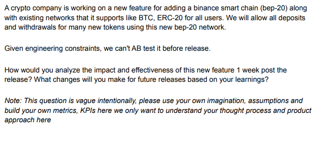

## Expected Data Model

1. Customer-Transaction Relationship
   - customer_id, tran_id
2. Transactions
   - tran_id, token, tran_amt, tran_type, network
- Consider transactions only after the launch

## Descriptive stats to find performance of the new network

At the end of Week 1

1. %ge of transactions (in terms of frequency and Amount) across different network
2. %ge of bep-20 transactions (in terms of frequency and Amount) across different transaction_type
3. %ge of customers using bep-20 out of customers who did a transaction
4. %ge of Re-activated customers for this week comparing to previous 2-3 weeks
5. %ge increase in Total transaction (frequency and volume) for this week comparing to previous 2-3 weeks
6. %ge of customers using bep-20 out of customers who did a transaction. and this can be done across GENDER, AGE, GEOGRAPHY, Device-OS, etc

Daily based

1. Plot Daily transactions (in terms of Frequency and Total Volume) in a line chart for different networks
2. Analyze any impact (decrease/increase) on daily churn rates for this week compared to previous 2-3 weeks

What changes will you make for future releases based on your learnings?

- If there is no significant increase in TOTAL VOLUMES/Transacting CUSTOMERs, then a customer survey or general market data can be analysed before coming up with a feature., given the constraints in the question.